# Julekalender 2023

Author

Lasse Hjorth Madsen

Published

April 25, 2026

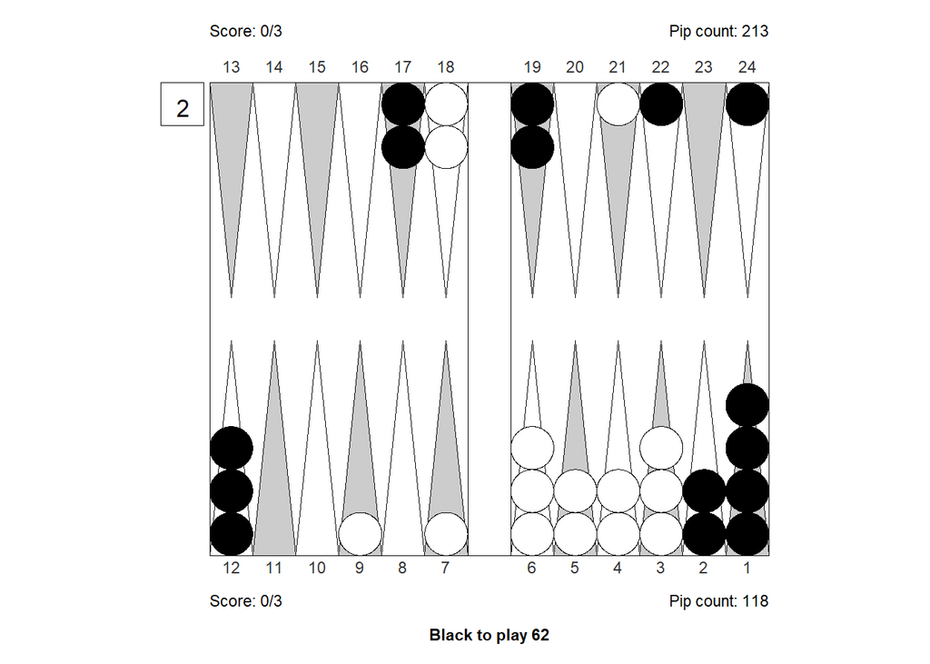

Dagens position er usædvanlig på flere måder: For det første er Sort i et 1-2-bagspil hvilket man ikke ser så ofte. For det andet er det lykkedes for Sort på uheldig vis at kombinere bagspillet med to malplacerede brikker på 3- og 1-punktet. For det tredje er GNU Backgammon og eXtreme Gammon enige om, at det bedste træk med 62 er klokkeklart. Desværre er de to programmer uenige om, hvad det bedste træk egentlig er.

Sort har en række muligheder med 62, og det kan være svært at vælge. Hvis man som jeg lærte at spille backgammon i slut 1980’erne, er der én ting som ligger helt fast: Det kan ikke komme på tale at spille 3/1 med 2’eren. Dengang, før computerne, lærte vi, at det var bedre at brække armen på langs end at lave sit 1-punkt i backgammon. Skete det, kunne man praktisk talt lige så godt give op. Og hvis man som Sort har et bagspil så er det endnu værre at lave 1-punktet, for man har brug for alle mand til at holde de bagerste punkter med, mens man samtidig bygger en blokade *foran* Hvid, så et eventuelt senere hit vinder.

Desværre føler GNU Backgammon, selv på 4-ply (svarende til XG’s 5-ply), at langt det bedste træk i stillingen er begyndertrækket: 24/18* 3/1.

Personligt ville jeg have foretrukket det enkle 24/18*/16* som på en virkelig god dag giver Sort mulighed for at vinde ved at gå fremad: Pumpe brikker ud i outfield’en og slå Hvid hjem igen og igen. Svigter planen (hvad den som regel gør), kan Sort altid falde tilbage på sit bagspil.

Der er også mulighed for det virkelig kreative 24/18* 6/4*, måske Sorts bedste change for nogensinde i sit liv at bygge en 6-punkts prime fra 8-punktet til 13-punktet. Hvem kan modstå fristelsen for en once-in-a-lifetime mulighed?

Endelig er der mellemting som 24/18* 13/11 eller 24/18* 8/6.

Kan man forestille sig, at GNU’s begyndertræk er det rigtige? Ved nærmere eftertanke er det måske ikke så dumt: Selvom det er at foretrække at bygge primen i rækkefølge, kan det vel også lade sig gøre at vinde med en lidt mere uordenligt blokade?

Men det her er jo en julehistorie, så den ender godt. Efter alt at dømme er 24/18*/16* alligevel det bedste træk – det er i hvert fald hvad XG får mest ud af i en stærk rollout. Selvom GNU Backgammon så vidt jeg ved efterhånden spiller næsten lige så godt som XG, så er denne stilling et blindt punkt. Det bliver ikke meget bedre af at at kigge nogle rul frem med 4-ply, for stillingen ligner sig selv også fire rul senere.

De kreative eller ekstremt kreative træk er heller ikke gode, hvilket på sin vis er lidt ærgerligt. Men 1-punktet er er altså den forkerte ide – men måske ikke *helt* lige så slemt som at brække armene på langs.

Matchstillingen her er 0-0 til 3, lidt anderledes end money game, men ikke nok til at ændre det store billede.

Her er rollout’en.

```
1. Rollout¹    24/18* 18/16*                eq:-0,344
Player:   38,23% (G:2,40% B:0,19%)
Opponent: 61,77% (G:38,50% B:24,23%)

2. Rollout¹    24/18* 13/11                 eq:-0,440 (-0,096)
Player:   36,07% (G:1,36% B:0,03%)
Opponent: 63,93% (G:41,39% B:30,72%)

3. Rollout¹    24/18* 8/6                   eq:-0,449 (-0,105)
Player:   35,92% (G:1,12% B:0,04%)
Opponent: 64,08% (G:42,22% B:28,57%)

4. Rollout¹    24/18* 3/1                   eq:-0,504 (-0,160)
Player:   32,57% (G:3,05% B:0,27%)
Opponent: 67,43% (G:37,60% B:20,36%)

5. Rollout²    24/18* 6/4*                  eq:-0,533 (-0,189)
Player:   34,82% (G:1,02% B:0,04%)
Opponent: 65,18% (G:47,13% B:35,37%)

1296 Games rolled with Variance Reduction.
Moves and cube decisions: 3-ply
```